# Apresentação do Trabalho Final de Econometria - Grupo 5

Grupo 5

22/03/2021

#### Integrantes do Grupo:

- Bruno Marcelino
- Daniel Rocha
- David Alexsander
- Felipe Robadel
- Gabriela Lamas

# QUESTÃO 1: Importação e Construção da Base de Dados

```r
# Cotações
ativos <- c("VALE3.SA", "PETR4.SA") # Localizar e Substituir o nome do ativo por outros
inicio <- as.Date("2010-01-04")
fim <- as.Date("2020-12-30")

cotacao <- ativos %>%
    tq_get(get = "stock.prices", from = inicio, to = fim) %>%
    mutate(adjusted = na.locf(adjusted))

# Retornos
df_retornos <- cotacao %>%
    group_by(symbol) %>%
    select(date, adjusted) %>%
    tq_transmute(select = adjusted,
                 mutate_fun = periodReturn,
                 period = "daily",
                 type = "log",
                 col_rename = "retorno") %>%
    spread(key = symbol, value = retorno)
```

# QUESTÃO 1: Importando a taxa SELIC da API do BACEN (de 2010 até hoje)

```r
Quandl.api_key('TC1ow5j6G7s4SFHTzgDz') # Acrescentando a chave da API - Comando necessário pra acessar o Quandl
selic_diaria <-  as.data.frame(Quandl("BCB/11", type = "xts")/100) # Importando a serie do selic do Bacen
df_selic <- selic_diaria %>%
    rownames_to_column() %>%
    tibble() %>%
    rename("date" = rowname, "selic" = V1) %>%
    mutate(selic = na.locf(selic))

df_selic$date <- as.Date(df_selic$date)

df_retornos <- df_retornos %>%
    left_join(df_selic, by = "date")
```

# QUESTÃO 1: Importando fatores de mercado do NEFIN-USP

```r
MKT_Factor <- read_excel("D:/Dropbox/UFMG/Programação/R/Métodos/Trabalho Final/Market_Factor.xls")
HML_Factor <- read_excel("D:/Dropbox/UFMG/Programação/R/Métodos/Trabalho Final/HML_Factor.xls")
SMB_Factor <- read_excel("D:/Dropbox/UFMG/Programação/R/Métodos/Trabalho Final/SMB_Factor.xls")

MKT <- MKT_Factor %>% select(date, Rm_minus_Rf) %>% rename("MKT" = Rm_minus_Rf)
MKT$date <- as.Date(MKT$date)

HML <- HML_Factor %>% select(date, HML)
HML$date <- as.Date(HML$date)

SMB <- SMB_Factor %>% select(date, SMB)
SMB$date <- as.Date(SMB$date)
```

# QUESTÃO 1: União dos dados e cálculo do prêmio de risco.

```r
df <- df_retornos %>%
    transmute("date" = date,
              "VALE3-Rf" = VALE3.SA - selic,
              "PETR4-Rf" = PETR4.SA - selic) %>%
    left_join(HML, by = "date") %>%
    left_join(SMB, by = "date") %>%
    left_join(MKT, by = "date")
```

# QUESTÃO 1: Estipulando modelos de regressão linear multivariada CAPM e Fama-French

```r
##### ------ CAPM ------ #####

capm_a <- lm(`VALE3-Rf` ~ MKT, data = df)
summary(capm_a)
```

```
##
## Call:
## lm(formula = `VALE3-Rf` ~ MKT, data = df)
##
## Residuals:
##       Min        1Q    Median        3Q       Max
## -0.264529 -0.010302 -0.000175  0.010420  0.109574
##
## Coefficients:
##               Estimate Std. Error t value Pr(>|t|)
## (Intercept) -0.0001020  0.0004143  -0.246    0.806
## MKT          1.1171720  0.0292169  38.237   <2e-16 ***
## ---
## Signif. codes:  0 '***' 0.001 '**' 0.01 '*' 0.05 '.' 0.1 ' ' 1
##
## Residual standard error: 0.0216 on 2716 degrees of freedom
##   (9 observations deleted due to missingness)
## Multiple R-squared:  0.3499, Adjusted R-squared:  0.3497
## F-statistic:  1462 on 1 and 2716 DF,  p-value: < 2.2e-16
```

```r
capm_b <- lm(`PETR4-Rf` ~ MKT, data = df)
summary(capm_b)
```

```
##
## Call:
## lm(formula = `PETR4-Rf` ~ MKT, data = df)
##
## Residuals:
##       Min        1Q    Median        3Q       Max
## -0.169081 -0.009702 -0.000240  0.010054  0.120967
##
## Coefficients:
##               Estimate Std. Error t value Pr(>|t|)
## (Intercept) -0.0005073  0.0003749  -1.353    0.176
## MKT          1.5914357  0.0264382  60.195   <2e-16 ***
## ---
## Signif. codes:  0 '***' 0.001 '**' 0.01 '*' 0.05 '.' 0.1 ' ' 1
##
## Residual standard error: 0.01954 on 2716 degrees of freedom
##   (9 observations deleted due to missingness)
## Multiple R-squared:  0.5716, Adjusted R-squared:  0.5714
## F-statistic:  3623 on 1 and 2716 DF,  p-value: < 2.2e-16
```

```r
##### ------ Fama-French ------ #####

ffrench_a <- lm(`VALE3-Rf` ~ MKT + HML + SMB, data = df)
summary(ffrench_a)
```

```
##
## Call:
## lm(formula = `VALE3-Rf` ~ MKT + HML + SMB, data = df)
##
## Residuals:
##       Min        1Q    Median        3Q       Max
## -0.266522 -0.010353 -0.000198  0.010145  0.118703
##
## Coefficients:
##               Estimate Std. Error t value Pr(>|t|)
## (Intercept) -0.0001518  0.0003998  -0.380    0.704
## MKT          0.9890755  0.0295762  33.442  < 2e-16 ***
## HML          0.7731214  0.0553759  13.961  < 2e-16 ***
## SMB         -0.3945778  0.0509501  -7.744 1.35e-14 ***
## ---
## Signif. codes:  0 '***' 0.001 '**' 0.01 '*' 0.05 '.' 0.1 ' ' 1
##
## Residual standard error: 0.02084 on 2714 degrees of freedom
##   (9 observations deleted due to missingness)
## Multiple R-squared:  0.3955, Adjusted R-squared:  0.3948
## F-statistic: 591.8 on 3 and 2714 DF,  p-value: < 2.2e-16
```

```r
ffrench_b <- lm(`PETR4-Rf` ~ MKT + HML + SMB, data = df)
summary(ffrench_b)
```

```
##
## Call:
## lm(formula = `PETR4-Rf` ~ MKT + HML + SMB, data = df)
##
## Residuals:
##       Min        1Q    Median        3Q       Max
## -0.176089 -0.009571 -0.000146  0.009764  0.117317
##
## Coefficients:
##               Estimate Std. Error t value Pr(>|t|)
## (Intercept) -0.0004992  0.0003691  -1.353    0.176
## MKT          1.5223555  0.0273048  55.754   <2e-16 ***
## HML          0.4623311  0.0511231   9.043   <2e-16 ***
## SMB         -0.0228563  0.0470372  -0.486    0.627
## ---
## Signif. codes:  0 '***' 0.001 '**' 0.01 '*' 0.05 '.' 0.1 ' ' 1
##
## Residual standard error: 0.01924 on 2714 degrees of freedom
##   (9 observations deleted due to missingness)
## Multiple R-squared:  0.5853, Adjusted R-squared:  0.5848
## F-statistic:  1277 on 3 and 2714 DF,  p-value: < 2.2e-16
```

# QUESTÃO 2 - Heterocedasticidade (antes da retirada de outliers)

##### Teste de Breusch-Pagan

O modelo CAPM inicialmente rejeita a hipótese nula do teste de Breusch-Pagan, o que o caracteriza como heterocedástico

```r
bptest(capm_b)
```

```
##
##  studentized Breusch-Pagan test
##
## data:  capm_b
## BP = 30.239, df = 1, p-value = 3.819e-08
```

O modelo de Fama-French inicialmente rejeita a hipótese nula, o que o caracteriza como heterocedástico

```r
bptest(ffrench_b)
```

```
##
##  studentized Breusch-Pagan test
##
## data:  ffrench_b
## BP = 70.237, df = 3, p-value = 3.798e-15
```

# QUESTÃO 2 - Correlação Serial (ANTES da retirada de outliers)

##### Teste de Breusch-Godfrey

O teste de Breusch-Godfrey indica que há correlação serial no modelo CAPM, rejeitando a hipótese nula.

```r
bgtest(capm_b)
```

```
##
##  Breusch-Godfrey test for serial correlation of order up to 1
##
## data:  capm_b
## LM test = 3.9944, df = 1, p-value = 0.04565
```

Já o teste de Breusch-Godfrey indica que não haveria correlação serial no modelo Fama-French, aceitando a hipótese nula.

```r
bgtest(ffrench_b)
```

```
##
##  Breusch-Godfrey test for serial correlation of order up to 1
##
## data:  ffrench_b
## LM test = 2.6885, df = 1, p-value = 0.1011
```

# QUESTÃO 2: Detecção e retirada de Outliers

```r
outliers_capm_b <- which(apply(influence.measures(capm_b)$is.inf, 1, any))
outliers_ffrench_b <- which(apply(influence.measures(ffrench_b)$is.inf, 1, any))

capm_b_corrigido <- lm(`PETR4-Rf` ~ MKT, data = df[-outliers_capm_b, ])
summary(capm_b_corrigido)
```

```
##
## Call:
## lm(formula = `PETR4-Rf` ~ MKT, data = df[-outliers_capm_b, ])
##
## Residuals:
##       Min        1Q    Median        3Q       Max
## -0.168424 -0.009130 -0.000203  0.009570  0.113486
##
## Coefficients:
##               Estimate Std. Error t value Pr(>|t|)
## (Intercept) -0.0006104  0.0003301  -1.849   0.0645 .
## MKT          1.5962565  0.0285102  55.989   <2e-16 ***
## ---
## Signif. codes:  0 '***' 0.001 '**' 0.01 '*' 0.05 '.' 0.1 ' ' 1
##
## Residual standard error: 0.01659 on 2525 degrees of freedom
##   (9 observations deleted due to missingness)
## Multiple R-squared:  0.5539, Adjusted R-squared:  0.5537
## F-statistic:  3135 on 1 and 2525 DF,  p-value: < 2.2e-16
```

```r
ffrench_b_corrigido <- lm(`PETR4-Rf` ~ MKT + HML + SMB, data = df[-outliers_ffrench_b, ])
summary(ffrench_b_corrigido)
```

```
##
## Call:
## lm(formula = `PETR4-Rf` ~ MKT + HML + SMB, data = df[-outliers_ffrench_b,
##     ])
##
## Residuals:
##       Min        1Q    Median        3Q       Max
## -0.156644 -0.009423 -0.000139  0.009336  0.109589
##
## Coefficients:
##               Estimate Std. Error t value Pr(>|t|)
## (Intercept) -0.0003876  0.0003167  -1.224    0.221
## MKT          1.4401821  0.0299337  48.112   <2e-16 ***
## HML          0.4524960  0.0512213   8.834   <2e-16 ***
## SMB         -0.0889610  0.0459495  -1.936    0.053 .
## ---
## Signif. codes:  0 '***' 0.001 '**' 0.01 '*' 0.05 '.' 0.1 ' ' 1
##
## Residual standard error: 0.01586 on 2505 degrees of freedom
##   (9 observations deleted due to missingness)
## Multiple R-squared:  0.5642, Adjusted R-squared:  0.5637
## F-statistic:  1081 on 3 and 2505 DF,  p-value: < 2.2e-16
```

# QUESTÃO 2 - Heterocedasticidade (APÓS a retirada de outliers)

##### Teste de Breusch-Pagan

O modelo CAPM rejeita a hipótese nula do teste de Breusch-Pagan, o que o caracteriza como heterocedástico

```r
bptest(capm_b_corrigido)
```

```
##
##  studentized Breusch-Pagan test
##
## data:  capm_b_corrigido
## BP = 27.818, df = 1, p-value = 1.333e-07
```

O modelo de Fama-French rejeita a hipótese nula, o que o caracteriza como heterocedástico

```r
bptest(ffrench_b_corrigido)
```

```
##
##  studentized Breusch-Pagan test
##
## data:  ffrench_b_corrigido
## BP = 21.033, df = 3, p-value = 0.0001036
```

# QUESTÃO 2 - Correlação Serial (APÓS a retirada de outliers)

##### Teste de Breusch-Godfrey

O teste de Breusch-Godfrey em ambos os modelos indica que agora não há correlação serial, por aceitarem a hipótese nula.

```r
bgtest(capm_b_corrigido)
```

```
##
##  Breusch-Godfrey test for serial correlation of order up to 1
##
## data:  capm_b_corrigido
## LM test = 0.0076611, df = 1, p-value = 0.9303
```

```r
bgtest(ffrench_b_corrigido)
```

```
##
##  Breusch-Godfrey test for serial correlation of order up to 1
##
## data:  ffrench_b_corrigido
## LM test = 0.75679, df = 1, p-value = 0.3843
```

# QUESTÃO 3: Normalidade dos Resíduos (antes das correções)

Ambos os testes mostraram que não há normalidade na distribuição dos resíduos de ambos os modelos (FF e CAPM)

```r
jarqueberaTest(residuals(capm_b_corrigido))
```

```
##
## Title:
##  Jarque - Bera Normalality Test
##
## Test Results:
##   STATISTIC:
##     X-squared: 11471.1073
##   P VALUE:
##     Asymptotic p Value: < 2.2e-16
##
## Description:
##  Wed Mar 24 22:54:45 2021 by user: Bruno Marcelino
```

```r
jarqueberaTest(residuals(ffrench_b_corrigido))
```

```
##
## Title:
##  Jarque - Bera Normalality Test
##
## Test Results:
##   STATISTIC:
##     X-squared: 3103.6045
##   P VALUE:
##     Asymptotic p Value: < 2.2e-16
##
## Description:
##  Wed Mar 24 22:54:45 2021 by user: Bruno Marcelino
```

# QUESTÃO 3: Correções para Heterocedasticidade

- Transformação logarítmica (não aplicável a variáveis negativas)
- Natureza das variáveis
- Outliers (já retirados)
- Regressão com Defasagem

# QUESTÃO 3: Regressão com Defasagem

```r
capm_teste <- dynlm(`PETR4-Rf` ~ MKT + HML + SMB + L(`PETR4-Rf`), data = df[-outliers_capm_b,])
summary(capm_teste)
```

```
##
## Time series regression with "numeric" data:
## Start = 1, End = 2527
##
## Call:
## dynlm(formula = `PETR4-Rf` ~ MKT + HML + SMB + L(`PETR4-Rf`),
##     data = df[-outliers_capm_b, ])
##
## Residuals:
##        Min         1Q     Median         3Q        Max
## -4.749e-17 -1.510e-18 -7.400e-19  1.000e-19  1.826e-15
##
## Coefficients:
##                 Estimate Std. Error    t value Pr(>|t|)
## (Intercept)   -1.304e-18  7.251e-19 -1.798e+00   0.0723 .
## MKT            3.277e-15  9.560e-17  3.428e+01  < 2e-16 ***
## HML            8.522e-16  1.110e-16  7.677e+00 2.31e-14 ***
## SMB           -2.600e-19  9.981e-17 -3.000e-03   0.9979
## L(`PETR4-Rf`)  1.000e+00  4.432e-17  2.256e+16  < 2e-16 ***
## ---
## Signif. codes:  0 '***' 0.001 '**' 0.01 '*' 0.05 '.' 0.1 ' ' 1
##
## Residual standard error: 3.642e-17 on 2522 degrees of freedom
##   (9 observations deleted due to missingness)
## Multiple R-squared:      1,  Adjusted R-squared:      1
## F-statistic: 2.936e+32 on 4 and 2522 DF,  p-value: < 2.2e-16
```

```r
bptest(capm_teste)
```

```
##
##  studentized Breusch-Pagan test
##
## data:  capm_teste
## BP = 1.703, df = 4, p-value = 0.7902
```

O modelo gerado pode até ser considerado homocedástico, porém há diversos problemas como o fato de o R^2 = 1. Não há possibilidade de continuar os cálculos pedidos com o novo modelo.

# QUESTÃO 3: Má especificação das formas funcionais

O teste RESET indicou que no caso do modelo CAPM, há má especificação das formas funcionais. Isso pode gerar heterocedasticidade

```r
resettest(capm_b_corrigido, power = c(2,3,4))
```

```
##
##  RESET test
##
## data:  capm_b_corrigido
## RESET = 44.926, df1 = 3, df2 = 2522, p-value < 2.2e-16
```

- Testando para várias potências, chegamos à conclusão de que a variável `MKT^4` é muito significante
- Alterando a forma funcional do modelo, a heterocedasticidade foi corrigida. Entretanto, o teste RESET ainda indica que há melhores formas funcionais. Paramos por aqui pois nosso objetivo foi atingido.

```r
capm_b_corrigido <- lm(`PETR4-Rf` ~ MKT + I(MKT^4), data = df[-outliers_capm_b, ])
summary(capm_b_corrigido)
```

```
##
## Call:
## lm(formula = `PETR4-Rf` ~ MKT + I(MKT^4), data = df[-outliers_capm_b,
##     ])
##
## Residuals:
##       Min        1Q    Median        3Q       Max
## -0.158737 -0.008998 -0.000365  0.009489  0.114081
##
## Coefficients:
##               Estimate Std. Error t value Pr(>|t|)
## (Intercept) -4.624e-04  3.229e-04  -1.432    0.152
## MKT          1.536e+00  2.840e-02  54.075   <2e-16 ***
## I(MKT^4)    -1.031e+03  9.415e+01 -10.950   <2e-16 ***
## ---
## Signif. codes:  0 '***' 0.001 '**' 0.01 '*' 0.05 '.' 0.1 ' ' 1
##
## Residual standard error: 0.01621 on 2524 degrees of freedom
##   (9 observations deleted due to missingness)
## Multiple R-squared:  0.5741, Adjusted R-squared:  0.5738
## F-statistic:  1701 on 2 and 2524 DF,  p-value: < 2.2e-16
```

```r
resettest(capm_b_corrigido, power = c(2,3,4)) # não corrigiu forma funcional
```

```
##
##  RESET test
##
## data:  capm_b_corrigido
## RESET = 5.5186, df1 = 3, df2 = 2521, p-value = 0.0008933
```

```r
bptest(capm_b_corrigido) # corrigiu heterocedasticidade
```

```
##
##  studentized Breusch-Pagan test
##
## data:  capm_b_corrigido
## BP = 0.40288, df = 2, p-value = 0.8176
```

```r
resettest(ffrench_b_corrigido, power = c(2,3,4,5,6)) # formas funcionais bem especificadas
```

```
##
##  RESET test
##
## data:  ffrench_b_corrigido
## RESET = 2.3029, df1 = 5, df2 = 2500, p-value = 0.0424
```

# QUESTÃO 3: Regressão Robusta

O método `coeftest` retorna os erros-padrão robustos (erros-padrão de White) atrelados a todos os coeficientes. Isso faz com que seus indicadores de significância sejam alterados, teoricamente em conjunto com a heterocedasticidade. Entretanto, não é possível armazenar esses dados em um objeto de classe “linear model” de forma a aplicar os próximos testes, por isso temos que descartá-lo.

```r
coeftest(ffrench_b_corrigido, vcov. = vcovHC)
```

```
##
## t test of coefficients:
##
##                Estimate  Std. Error t value  Pr(>|t|)
## (Intercept) -0.00038760  0.00031635 -1.2252    0.2206
## MKT          1.44018210  0.03943979 36.5160 < 2.2e-16 ***
## HML          0.45249600  0.05995318  7.5475 6.173e-14 ***
## SMB         -0.08896100  0.05912069 -1.5047    0.1325
## ---
## Signif. codes:  0 '***' 0.001 '**' 0.01 '*' 0.05 '.' 0.1 ' ' 1
```

O método lmrob cria regressões que aceitam o parâmetro que define a matriz de covariâncias a ser utilizada, que é a matriz de White. A partir daí, cria-se um objeto que teoricamente corrige a heterocedasticidade, e que será utilizado nos próximos passos.

```r
ffrench_b_corrigido <- lmrob(`PETR4-Rf` ~ MKT + HML + SMB, data = df[-outliers_ffrench_b,], cov = ".vcov.w")
summary(ffrench_b_corrigido)
```

```
##
## Call:
## lmrob(formula = `PETR4-Rf` ~ MKT + HML + SMB, data = df[-outliers_ffrench_b,
##     ], cov = ".vcov.w")
##  \--> method = "MM"
## Residuals:
##        Min         1Q     Median         3Q        Max
## -0.1568646 -0.0092791 -0.0002121  0.0094187  0.1107444
##
## Coefficients:
##               Estimate Std. Error t value Pr(>|t|)
## (Intercept) -0.0004608  0.0002979  -1.547    0.122
## MKT          1.4247470  0.0289937  49.140  < 2e-16 ***
## HML          0.3784315  0.0489543   7.730 1.54e-14 ***
## SMB         -0.0580242  0.0443167  -1.309    0.191
## ---
## Signif. codes:  0 '***' 0.001 '**' 0.01 '*' 0.05 '.' 0.1 ' ' 1
##
## Robust residual standard error: 0.01381
##   (9 observations deleted due to missingness)
## Multiple R-squared:  0.5861, Adjusted R-squared:  0.5856
## Convergence in 11 IRWLS iterations
##
## Robustness weights:
##  7 observations c(1928,1929,1931,2342,2345,2346,2347)
##   are outliers with |weight| = 0 ( < 4e-05);
##  224 weights are ~= 1. The remaining 2278 ones are summarized as
##    Min. 1st Qu.  Median    Mean 3rd Qu.    Max.
## 0.01688 0.86120 0.95090 0.89220 0.98550 0.99900
## Algorithmic parameters:
##        tuning.chi                bb        tuning.psi        refine.tol
##         1.548e+00         5.000e-01         4.685e+00         1.000e-07
##           rel.tol         scale.tol         solve.tol       eps.outlier
##         1.000e-07         1.000e-10         1.000e-07         3.986e-05
##             eps.x warn.limit.reject warn.limit.meanrw
##         1.819e-12         5.000e-01         5.000e-01
##      nResample         max.it       best.r.s       k.fast.s          k.max
##            500             50              2              1            200
##    maxit.scale      trace.lev            mts     compute.rd fast.s.large.n
##            200              0           1000              0           2000
##                   psi           subsampling                   cov
##            "bisquare"         "nonsingular"             ".vcov.w"
## compute.outlier.stats
##                  "SM"
## seed : int(0)
```

# QUESTÃO 3: Normalidade dos Resíduos (após as correções)

As correções para heterocedasticidade e correlação serial não foram capazes de fazer a distribuição dos resíduos de ambos os modelos (FF e CAPM) se tornar normal.

```r
jarqueberaTest(resid(capm_b_corrigido))
```

```
##
## Title:
##  Jarque - Bera Normalality Test
##
## Test Results:
##   STATISTIC:
##     X-squared: 5097.404
##   P VALUE:
##     Asymptotic p Value: < 2.2e-16
##
## Description:
##  Wed Mar 24 22:54:46 2021 by user: Bruno Marcelino
```

```r
jarqueberaTest(resid(ffrench_b_corrigido))
```

```
##
## Title:
##  Jarque - Bera Normalality Test
##
## Test Results:
##   STATISTIC:
##     X-squared: 3216.0926
##   P VALUE:
##     Asymptotic p Value: < 2.2e-16
##
## Description:
##  Wed Mar 24 22:54:46 2021 by user: Bruno Marcelino
```

# QUESTÃO 3: Tratamento dos modelos antigos

```r
outliers_capm_a <- which(apply(influence.measures(capm_a)$is.inf, 1, any))
outliers_ffrench_a <- which(apply(influence.measures(ffrench_a)$is.inf, 1, any))

capm_a_corrigido <- lm(`VALE3-Rf` ~ MKT, data = df[-outliers_capm_a, ])
summary(capm_a_corrigido)
```

```
##
## Call:
## lm(formula = `VALE3-Rf` ~ MKT, data = df[-outliers_capm_a, ])
##
## Residuals:
##       Min        1Q    Median        3Q       Max
## -0.264607 -0.009687  0.000121  0.010076  0.085728
##
## Coefficients:
##               Estimate Std. Error t value Pr(>|t|)
## (Intercept) -0.0005354  0.0003616  -1.481    0.139
## MKT          1.0844184  0.0314316  34.501   <2e-16 ***
## ---
## Signif. codes:  0 '***' 0.001 '**' 0.01 '*' 0.05 '.' 0.1 ' ' 1
##
## Residual standard error: 0.0181 on 2504 degrees of freedom
##   (9 observations deleted due to missingness)
## Multiple R-squared:  0.3222, Adjusted R-squared:  0.3219
## F-statistic:  1190 on 1 and 2504 DF,  p-value: < 2.2e-16
```

```r
ffrench_a_corrigido <- lm(`VALE3-Rf` ~ MKT + HML + SMB, data = df[-outliers_ffrench_a, ])
summary(ffrench_a_corrigido)
```

```
##
## Call:
## lm(formula = `VALE3-Rf` ~ MKT + HML + SMB, data = df[-outliers_ffrench_a,
##     ])
##
## Residuals:
##       Min        1Q    Median        3Q       Max
## -0.267294 -0.009785  0.000067  0.009628  0.085303
##
## Coefficients:
##               Estimate Std. Error t value Pr(>|t|)
## (Intercept) -0.0004227  0.0003472  -1.217    0.224
## MKT          0.8685669  0.0328644  26.429  < 2e-16 ***
## HML          0.8132063  0.0552988  14.706  < 2e-16 ***
## SMB         -0.3173877  0.0499114  -6.359 2.41e-10 ***
## ---
## Signif. codes:  0 '***' 0.001 '**' 0.01 '*' 0.05 '.' 0.1 ' ' 1
##
## Residual standard error: 0.0173 on 2480 degrees of freedom
##   (9 observations deleted due to missingness)
## Multiple R-squared:  0.3678, Adjusted R-squared:  0.3671
## F-statistic:   481 on 3 and 2480 DF,  p-value: < 2.2e-16
```

```r
# Correlação Serial

bgtest(capm_a_corrigido) # não há correl serial
```

```
##
##  Breusch-Godfrey test for serial correlation of order up to 1
##
## data:  capm_a_corrigido
## LM test = 0.083018, df = 1, p-value = 0.7732
```

```r
bgtest(ffrench_a_corrigido) # não há correl serial
```

```
##
##  Breusch-Godfrey test for serial correlation of order up to 1
##
## data:  ffrench_a_corrigido
## LM test = 0.11187, df = 1, p-value = 0.738
```

```r
# Heterocedasticidade
bptest(capm_a_corrigido) # Homocedástico
```

```
##
##  studentized Breusch-Pagan test
##
## data:  capm_a_corrigido
## BP = 0.48538, df = 1, p-value = 0.486
```

```r
bptest(ffrench_a_corrigido) # Homocedástico
```

```
##
##  studentized Breusch-Pagan test
##
## data:  ffrench_a_corrigido
## BP = 4.1325, df = 3, p-value = 0.2475
```

# QUESTÃO 4: Teste da hipótese “Beta = 1”

- O teste foi feito por meio da estatística F, em que o modelo restrito trata o coeficiente beta analisado como sendo fixo.
- Em todos os testes aceitamos o modelo irrestrito, ou seja, a hipótese de que o beta = 1 não é significante.

```r
linearHypothesis(capm_a_corrigido, "MKT=1") # não significante
```

```
## Linear hypothesis test
##
## Hypothesis:
## MKT = 1
##
## Model 1: restricted model
## Model 2: `VALE3-Rf` ~ MKT
##
##   Res.Df     RSS Df Sum of Sq      F   Pr(>F)
## 1   2505 0.82272
## 2   2504 0.82036  1 0.0023632 7.2134 0.007284 **
## ---
## Signif. codes:  0 '***' 0.001 '**' 0.01 '*' 0.05 '.' 0.1 ' ' 1
```

```r
linearHypothesis(capm_b_corrigido, c("MKT=1")) # não significante
```

```
## Linear hypothesis test
##
## Hypothesis:
## MKT = 1
##
## Model 1: restricted model
## Model 2: `PETR4-Rf` ~ MKT + I(MKT^4)
##
##   Res.Df     RSS Df Sum of Sq      F    Pr(>F)
## 1   2525 0.75710
## 2   2524 0.66353  1  0.093575 355.95 < 2.2e-16 ***
## ---
## Signif. codes:  0 '***' 0.001 '**' 0.01 '*' 0.05 '.' 0.1 ' ' 1
```

```r
linearHypothesis(ffrench_a_corrigido, "MKT=1") # não significante
```

```
## Linear hypothesis test
##
## Hypothesis:
## MKT = 1
##
## Model 1: restricted model
## Model 2: `VALE3-Rf` ~ MKT + HML + SMB
##
##   Res.Df     RSS Df Sum of Sq      F   Pr(>F)
## 1   2481 0.74725
## 2   2480 0.74246  1 0.0047883 15.994 6.54e-05 ***
## ---
## Signif. codes:  0 '***' 0.001 '**' 0.01 '*' 0.05 '.' 0.1 ' ' 1
```

```r
linearHypothesis(ffrench_b_corrigido, "MKT=1") # não significante
```

```
## Linear hypothesis test
##
## Hypothesis:
## MKT = 1
##
## Model 1: restricted model
## Model 2: `PETR4-Rf` ~ MKT + HML + SMB
##
##   Res.Df Df  Chisq Pr(>Chisq)
## 1   2506
## 2   2505  1 214.61  < 2.2e-16 ***
## ---
## Signif. codes:  0 '***' 0.001 '**' 0.01 '*' 0.05 '.' 0.1 ' ' 1
```

# QUESTÃO 4: Risco dos ativos

```r
summary(capm_a_corrigido) # Beta = 1.08
```

```
##
## Call:
## lm(formula = `VALE3-Rf` ~ MKT, data = df[-outliers_capm_a, ])
##
## Residuals:
##       Min        1Q    Median        3Q       Max
## -0.264607 -0.009687  0.000121  0.010076  0.085728
##
## Coefficients:
##               Estimate Std. Error t value Pr(>|t|)
## (Intercept) -0.0005354  0.0003616  -1.481    0.139
## MKT          1.0844184  0.0314316  34.501   <2e-16 ***
## ---
## Signif. codes:  0 '***' 0.001 '**' 0.01 '*' 0.05 '.' 0.1 ' ' 1
##
## Residual standard error: 0.0181 on 2504 degrees of freedom
##   (9 observations deleted due to missingness)
## Multiple R-squared:  0.3222, Adjusted R-squared:  0.3219
## F-statistic:  1190 on 1 and 2504 DF,  p-value: < 2.2e-16
```

```r
summary(capm_b_corrigido) # Beta = 1.54
```

```
##
## Call:
## lm(formula = `PETR4-Rf` ~ MKT + I(MKT^4), data = df[-outliers_capm_b,
##     ])
##
## Residuals:
##       Min        1Q    Median        3Q       Max
## -0.158737 -0.008998 -0.000365  0.009489  0.114081
##
## Coefficients:
##               Estimate Std. Error t value Pr(>|t|)
## (Intercept) -4.624e-04  3.229e-04  -1.432    0.152
## MKT          1.536e+00  2.840e-02  54.075   <2e-16 ***
## I(MKT^4)    -1.031e+03  9.415e+01 -10.950   <2e-16 ***
## ---
## Signif. codes:  0 '***' 0.001 '**' 0.01 '*' 0.05 '.' 0.1 ' ' 1
##
## Residual standard error: 0.01621 on 2524 degrees of freedom
##   (9 observations deleted due to missingness)
## Multiple R-squared:  0.5741, Adjusted R-squared:  0.5738
## F-statistic:  1701 on 2 and 2524 DF,  p-value: < 2.2e-16
```

```r
summary(ffrench_a_corrigido) # Beta = 0.87
```

```
##
## Call:
## lm(formula = `VALE3-Rf` ~ MKT + HML + SMB, data = df[-outliers_ffrench_a,
##     ])
##
## Residuals:
##       Min        1Q    Median        3Q       Max
## -0.267294 -0.009785  0.000067  0.009628  0.085303
##
## Coefficients:
##               Estimate Std. Error t value Pr(>|t|)
## (Intercept) -0.0004227  0.0003472  -1.217    0.224
## MKT          0.8685669  0.0328644  26.429  < 2e-16 ***
## HML          0.8132063  0.0552988  14.706  < 2e-16 ***
## SMB         -0.3173877  0.0499114  -6.359 2.41e-10 ***
## ---
## Signif. codes:  0 '***' 0.001 '**' 0.01 '*' 0.05 '.' 0.1 ' ' 1
##
## Residual standard error: 0.0173 on 2480 degrees of freedom
##   (9 observations deleted due to missingness)
## Multiple R-squared:  0.3678, Adjusted R-squared:  0.3671
## F-statistic:   481 on 3 and 2480 DF,  p-value: < 2.2e-16
```

```r
summary(ffrench_b_corrigido) # Beta = 1.42
```

```
##
## Call:
## lmrob(formula = `PETR4-Rf` ~ MKT + HML + SMB, data = df[-outliers_ffrench_b,
##     ], cov = ".vcov.w")
##  \--> method = "MM"
## Residuals:
##        Min         1Q     Median         3Q        Max
## -0.1568646 -0.0092791 -0.0002121  0.0094187  0.1107444
##
## Coefficients:
##               Estimate Std. Error t value Pr(>|t|)
## (Intercept) -0.0004608  0.0002979  -1.547    0.122
## MKT          1.4247470  0.0289937  49.140  < 2e-16 ***
## HML          0.3784315  0.0489543   7.730 1.54e-14 ***
## SMB         -0.0580242  0.0443167  -1.309    0.191
## ---
## Signif. codes:  0 '***' 0.001 '**' 0.01 '*' 0.05 '.' 0.1 ' ' 1
##
## Robust residual standard error: 0.01381
##   (9 observations deleted due to missingness)
## Multiple R-squared:  0.5861, Adjusted R-squared:  0.5856
## Convergence in 11 IRWLS iterations
##
## Robustness weights:
##  7 observations c(1928,1929,1931,2342,2345,2346,2347)
##   are outliers with |weight| = 0 ( < 4e-05);
##  224 weights are ~= 1. The remaining 2278 ones are summarized as
##    Min. 1st Qu.  Median    Mean 3rd Qu.    Max.
## 0.01688 0.86120 0.95090 0.89220 0.98550 0.99900
## Algorithmic parameters:
##        tuning.chi                bb        tuning.psi        refine.tol
##         1.548e+00         5.000e-01         4.685e+00         1.000e-07
##           rel.tol         scale.tol         solve.tol       eps.outlier
##         1.000e-07         1.000e-10         1.000e-07         3.986e-05
##             eps.x warn.limit.reject warn.limit.meanrw
##         1.819e-12         5.000e-01         5.000e-01
##      nResample         max.it       best.r.s       k.fast.s          k.max
##            500             50              2              1            200
##    maxit.scale      trace.lev            mts     compute.rd fast.s.large.n
##            200              0           1000              0           2000
##                   psi           subsampling                   cov
##            "bisquare"         "nonsingular"             ".vcov.w"
## compute.outlier.stats
##                  "SM"
## seed : int(0)
```

Analisando os betas do fator de mercado para ambas as ações, tanto o modelo de Fama-French quanto o modelo CAPM propuseram que, de maneira significante, a ação da PETR4 está mais exposta ao risco sistêmico, por apresentar maior beta (que representa a maior influência do fator mercado no retorno da ação).

# QUESTÃO 5: Teste F entre os modelos do ativo mais arriscado

- Não é possível realizar o teste F convencional entre dois modelos que possuem quantidades de observações diferentes

```r
Anova(capm_b_corrigido, ffrench_b_corrigido)
```

```
## Anova Table (Type II tests)
##
## Response: PETR4-Rf
##            Sum Sq   Df F value    Pr(>F)
## MKT       0.76871    1 4030.01 < 2.2e-16 ***
## I(MKT^4)  0.03152    1  165.24 < 2.2e-16 ***
## Residuals 0.47782 2505
## ---
## Signif. codes:  0 '***' 0.001 '**' 0.01 '*' 0.05 '.' 0.1 ' ' 1
```

# QUESTÃO 6: Teste da hipótese “Alfa = 0”

```r
linearHypothesis(ffrench_b_corrigido, "(Intercept) = 0")
```

```
## Linear hypothesis test
##
## Hypothesis:
## (Intercept) = 0
##
## Model 1: restricted model
## Model 2: `PETR4-Rf` ~ MKT + HML + SMB
##
##   Res.Df Df Chisq Pr(>Chisq)
## 1   2506
## 2   2505  1 2.392      0.122
```

- O teste de hipótese corrobora com o p-valor do teste-t fornecido pelo sumário do modelo, que diz que o valor obtido para o intercepto era não era estatisticamente significante. O p-valor do teste aceita o modelo restrito de que o intercepto é igual a zero.

# QUESTÃO 7 (Gráfico Resíduos x Tempo - Ativo A)

Podemos notar como o resíduo se comporta antes e após a retirada de dos outliers no modelo de Fama-French

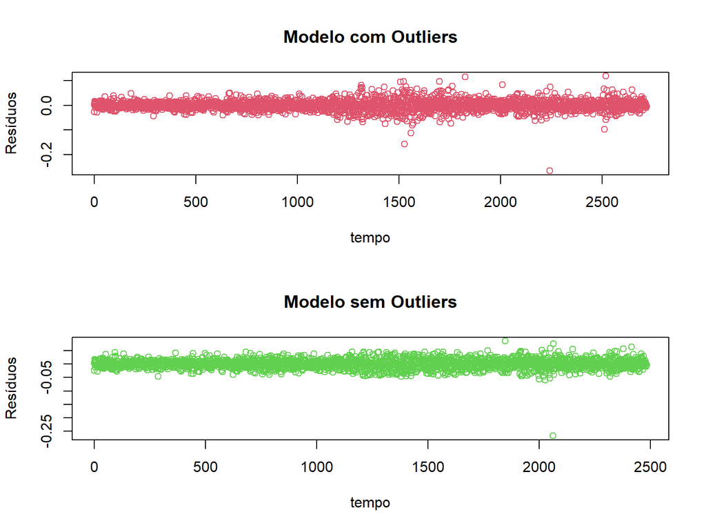

```r
graf <- par(no.readonly = TRUE)
par(mfrow=c(2,1))

plot((ffrench_a$residuals) ,main= "Modelo com Outliers", xlab="tempo", ylab="Resíduos" ,col=2)
plot((ffrench_a_corrigido$residuals) ,main= "Modelo sem Outliers", xlab="tempo", ylab="Resíduos",col=3 )
```

# QUESTÃO 7 (Gráfico Resíduos^2 x Tempo - Ativo A)

Notamos que após a retirada dos Outliers os erros padrões se apresentam de forma mais comportada em torno do 0. Isso reforça, agora de forma visual, que ao fazer o teste de correlação serial na Questão 2 o modelo não apresentava média igual a O. Isso foi corrigido com a retirada dos Outliers, porém ainda poderia ser melhorado.

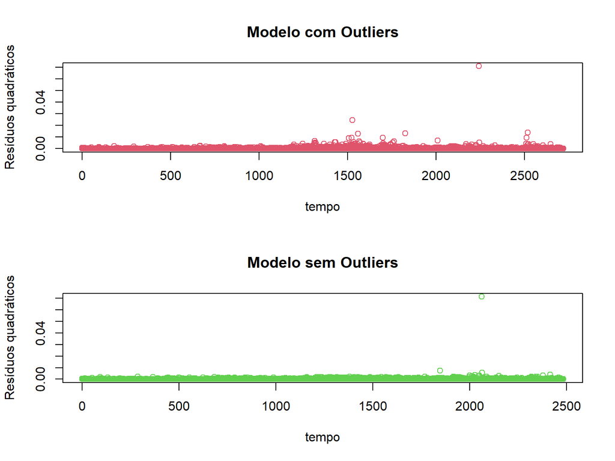

```r
graf <- par(no.readonly = TRUE)
par(mfrow=c(2,1))

plot((ffrench_a$residuals)^2 ,main= "Modelo com Outliers", xlab="tempo", ylab="Resíduos quadráticos" ,col=2)
plot((ffrench_a_corrigido$residuals)^2 ,main= "Modelo sem Outliers", xlab="tempo", ylab="Resíduos quadráticos",col=3 )
```

# QUESTÃO 7 (Gráfico Resíduos x Tempo - Ativo B)

O mesmo ocorre com o outro ativo (Fama-French B)

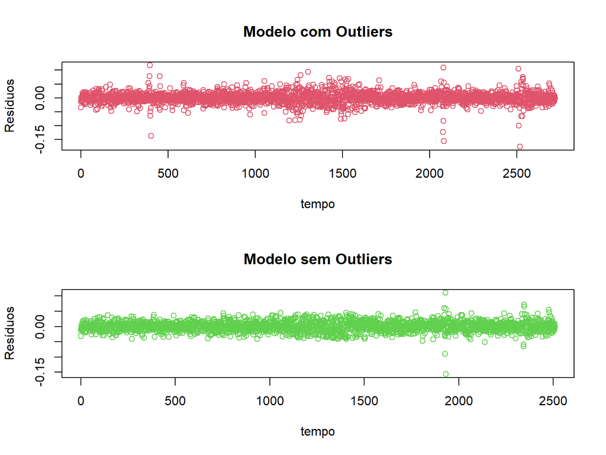

```r
graf <- par(no.readonly = TRUE)
par(mfrow=c(2,1))

plot((ffrench_b$residuals) ,main= "Modelo com Outliers", xlab="tempo", ylab="Resíduos" ,col=2)
plot((ffrench_b_corrigido$residuals) ,main= "Modelo sem Outliers", xlab="tempo", ylab="Resíduos",col=3 )
```

# QUESTÃO 7 (Gráfico Resíduos^2 x Tempo - Ativo B)

Notamos que após a retirada dos Outliers os erros padrões se apresentam de forma mais comportada em torno do 0. Isso reforça, agora de forma visual, que ao fazer o teste de correlação serial na questão 2 o modelo não apresentava média igual a O. Isso foi corrigido com a retirada dos outliers, porém ainda poderia ser melhorado.

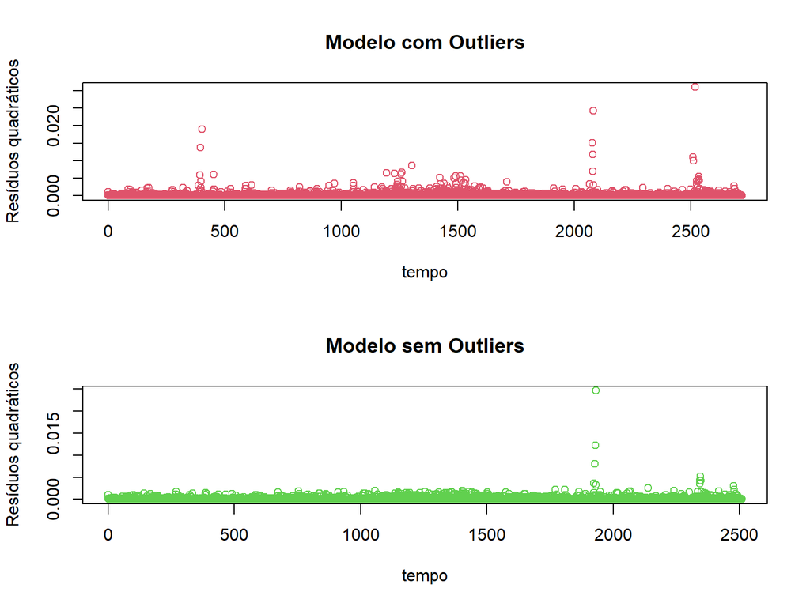

```r
graf <- par(no.readonly = TRUE)
par(mfrow=c(2,1))

plot((ffrench_b$residuals)^2 ,main= "Modelo com Outliers", xlab="tempo", ylab="Resíduos quadráticos" ,col=2)
plot((ffrench_b_corrigido$residuals)^2 ,main= "Modelo sem Outliers", xlab="tempo", ylab="Resíduos quadráticos",col=3 )
```

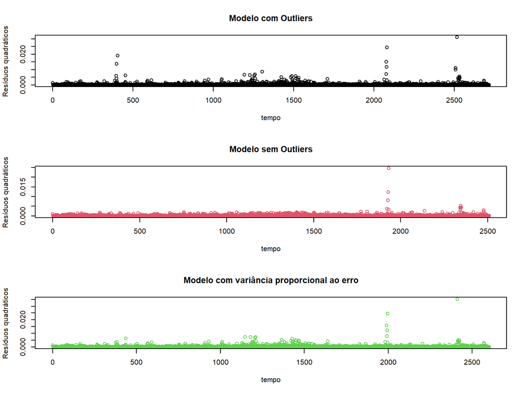

```r
varProp =lm(`PETR4-Rf` ~ MKT, weigh= 1/abs(MKT) ,data = df)
outliers_varProp <- which(apply(influence.measures(varProp)$is.inf, 1, any))
varProp_corrigido <- lmrob(`PETR4-Rf` ~ MKT + HML + SMB, data = df[-outliers_varProp,], cov = ".vcov.w")

graf <- par(no.readonly = TRUE)

par(mfrow=c(3,1))

plot((ffrench_b$residual)^2 ,main= "Modelo com Outliers", xlab="tempo", ylab="Resíduos quadráticos" ,col=1)
plot((ffrench_b_corrigido$residuals)^2 ,main= "Modelo sem Outliers", xlab="tempo", ylab="Resíduos quadráticos" ,col=2)
plot((residuals(varProp_corrigido)^2),main= "Modelo com variância proporcional ao erro", xlab="tempo", ylab="Resíduos quadráticos" ,col=3)
```